# LCAS Report

LCAS team

2023-05-11

This document provides a sample report for automated insights into drivers and outcomes of crop prodcution systems at landscape level as part of the LCAS system.

## Initial overview

First, we need to load the datast of interest. Make sure it has been cleaned properly using the cleaning files.

We can then produce some key statistics to provide and overview of the dataset.

The dataset contains data from the following countries: **India,** from the years **2017, 2018** for **Rice**.

The average landholding size was **1.37** ha and the average size of the largest plot was **0.302** ha.

Data has been collected in the following states/provinces: **Bihar, UttarPradesh, Odisha, Andhra Pradesh, Chattisgarh, WestBengal, Haryana, Punjab**.

The dataset contains **15,212** samples. And the following distribution of samples across the sample provinces/states:

| State/Province | % of samples |
| --- | --- |
| Bihar | 46.94 |
| UttarPradesh | 16.78 |
| WestBengal | 10.10 |
| Odisha | 8.80 |
| Andhra Pradesh | 8.76 |
| Chattisgarh | 3.32 |
| Haryana | 2.74 |
| Punjab | 2.55 |

## Yield and crop variety patterns

The average yield across the dataset is **4.36 t ha<sup>-1</sup>** with a standard deviation of **1.4 t ha<sup>-1</sup>**.

The yield distribution looks as follows:

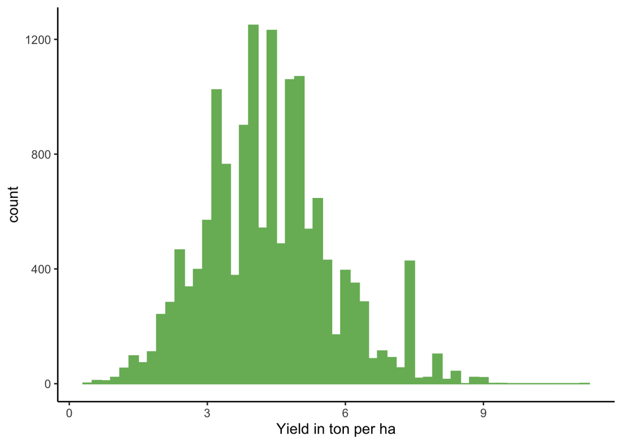

The mean yield and standard deviation per state/province in descending order:

| State/Province | Mean yield | Standard Deviation |
| --- | --- | --- |
| Punjab | 7.45 | 1.20 |
| Haryana | 6.62 | 1.06 |
| Andhra Pradesh | 5.47 | 1.28 |
| UttarPradesh | 4.28 | 1.06 |
| WestBengal | 4.24 | 1.36 |
| Bihar | 4.02 | 1.15 |
| Chattisgarh | 3.97 | 1.15 |
| Odisha | 3.94 | 1.27 |

The same table per variety looks as follows:

| Variety Type | Mean yield | Standard Deviation |
| --- | --- | --- |
| Improved | 4.40 | 1.41 |
| Local | 4.39 | 1.72 |
| Hybrid | 4.24 | 1.28 |
| Unknown | 4.17 | 1.42 |
| Basmati | 4.07 | 1.23 |

The most common varieites grown are the following:

| Variety name | % of samples |
| --- | --- |
| MTU_7029 | 0.16 |
| Arize6444Gold | 0.13 |
| BPT5204 | 0.05 |
| MTU7029 | 0.05 |
| SambaMahsuri_BPT5204 | 0.04 |

## Management practices

On average, rice crops have been (trans)planted or directly sown on **12. of July** and harvested on **14. of November** with **5.35** irrigation events and a total of **55.26** kg urea and **1.45** kg npk applied per plot.